# Lab 11 - Bioinformatics

In this exercise, we use the course data set (the BeatAML2 cohort), look at the data and see whether there are patterns of expression among genes and patients. You will: 1) get the gene expression data and have brief information about the data; 2) do filtering; 3) observe the similarities/dissimilarities between samples and between genes; 4) get familiar with different distance measures.

Researchers want to investigate the biomarkers that make the difference between patients with ”Complete Response” vs ”Refractory” after the first treatment using gene expression data, we use read count data (rnaCounts) and its normalized data (rnaNorm) in this exercise. More details about the normalization of RNA-seq data will be discussed in Lecture 14. We first load and extract relevant data for the investigation.

```
load(file="BeatAML2_clean.RData")
pick=clinical_data$responseToInductionTx %in% c("Complete Response","Refractory")
rnaCounts=rnaCounts[,pick]
rnaNorm=rnaNorm[,pick]
clinical_data=clinical_data[pick,]
```

### A quick look

We look at the selected data for analysis with basic information

```
dim(rnaCounts)
```

```
[1] 56124   312
```

```
dim(rnaNorm)
```

```
[1] 56124   312
```

```
table(clinical_data$responseToInductionTx)
```

```
Complete Response        Refractory
              214                98
```

We see that the expression data set consists of 56124 features (genes) and 312 samples from AML patients. From the clinical data, we observe there are 214 AML patients with Complete Response vs 98 AML cases of Refractory.

### Filtering features

We start by filtering the expression data. We focus on using only curated genes in the gene name database of HUGO Gene Nomenclature Committee. First, we need a mapping between Ensembl gene ID and gene symbol of HUGO Gene Nomenclature Committee. We already prepared the mapping and stored it in geneMap object. If you want to do it for new data, we need to install the Bioconductor package biomaRt and use the function getBM() to extract the corresponding HGNC symbol from Ensembl gene ID as follows.

```
if (!require("BiocManager", quietly = TRUE)) install.packages("BiocManager")
```

```
Bioconductor version 3.20 (BiocManager 1.30.25), R 4.4.2 (2024-10-31 ucrt)
```

```
BiocManager::install("biomaRt")
```

[output not shown]

[output not shown]

```
a
```

[output not shown]

[output not shown]

[output not shown]

[output not shown]

[output cut: 279 more lines]

```
library('biomaRt')
```

```
mart <- useDataset("hsapiens_gene_ensembl", useMart("ensembl"))
geneMap <- getBM(filters= "ensembl_gene_id",
attributes= c("ensembl_gene_id","hgnc_symbol"),
values=rownames(rnaNorm),mart= mart)
```

[output not shown]

We print several lines of geneMap and observe the number of rows:

```
head(geneMap)
```

|  | ensembl_gene_id | hgnc_symbol |
| --- | --- | --- |
| 1 | ENSG00000000003 | TSPAN6 |
| 2 | ENSG00000000005 | TNMD |
| 3 | ENSG00000000419 | DPM1 |
| 4 | ENSG00000000457 | SCYL3 |
| 5 | ENSG00000000460 | FIRRM |
| 6 | ENSG00000000938 | FGR |

```
nrow(geneMap)
```

```
[1] 54979
```

```
p=which(geneMap$hgnc_symbol=="")
length(p)
```

```
[1] 16410
```

```
geneMap=geneMap[-p, ]
```

Remove features with duplicated gene names:

```
d=geneMap$ensembl_gene_id[which(duplicated(geneMap$hgnc_symbol) |
duplicated(geneMap$ensembl_gene_id))]
p=which(geneMap$ensembl_gene_id %in% d)
length(p)
```

```
[1] 15
```

```
geneMap=geneMap[-p, ]
```

Now, apply the filters for gene expression data:

```
gexCount=rnaCounts[rownames(rnaCounts) %in% geneMap$ensembl_gene_id,]
gexNorm=rnaNorm[rownames(rnaNorm) %in% geneMap$ensembl_gene_id,]
```

Remove genes not expressed (read count ≤ 2) in more than 90% samples

```
x=apply(gexCount, 1, function(x) sum(x > 2))
p=x > ncol(gexCount)*0.10
sum(p)
```

```
[1] 26039
```

```
gexCount=gexCount[p,]
gexNorm=gexNorm[p,]
```

Remove genes with normalized expression IQR ≤ the median of IQR

```
q3=apply(gexNorm, 1, function(x) quantile(x, 0.75))
q1=apply(gexNorm, 1, function(x) quantile(x, 0.25))
iqr=q3-q1
p=which(iqr > quantile(iqr, probs=0.5 ))
length(p)
```

```
[1] 13019
```

```
gexCount=gexCount[p,]
gexNorm=gexNorm[p,]
dim(gexNorm)
```

```
[1] 13019   312
```

Now we use filtered and normalized gene expression (gexNorm) for further analysis. For convenience, we assign it to a new object gex which we will use from now on.

```
gex=gexNorm
```

```
hist(gex[1,], main="Histogram of a gene")
```

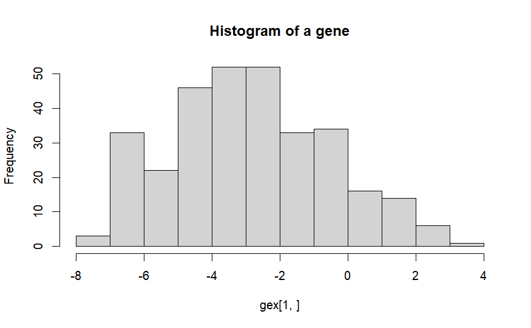

Do you think the normalized gene expression data approximates the normal distribution? Now, we plot to compare gene 1 to the next two genes:

```
par(mfrow=c(1,2)) #setting up to put two plots in one figure
plot(gex[1,],gex[2,], main="Gene 1 vs gene 2")
abline(0,1)
```

```
plot(gex[1,],gex[3,], main="Gene 1 vs gene 3 ")
abline(0,1)
```

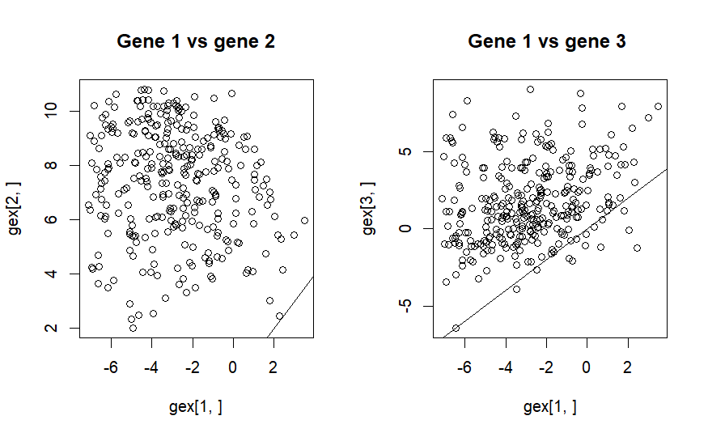

In the plots, each point presents one sample: the black line is the diagonal line that if a sample stays in the line, two genes have an equal expression in that sample. From the plots, it is not very clear but gene 1 is likely more similar to gene 3 than gene 2. We do similar plots for samples:

```
par(mfrow=c(1,2))
plot(gex[,1],gex[,2], main="Sample 1 vs Sample 2")
abline(0,1)
```

```
plot(gex[,1],gex[,3], main="Sample 1 vs Sample 3")
abline(0,1)
```

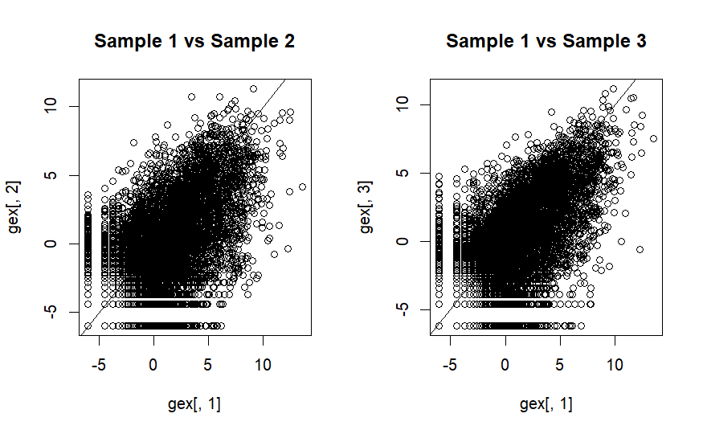

There are many more points in the figures, if we enlarge the figures, sample 1 is likely more dissimilar to sample 2 rather than sample 3. Now we quantify this by computing the distances between them.

We start with samples, by defining a distance matrix between samples; to do so, we have to flip the expression matrix (swap rows and columns) using the function t() (for transpose), because the function dist calculates distances between the rows of a matrix (i.e. along the columns):

```
distSample = dist(t(gex))
as.matrix(distSample)[1:10,1:10]
```

```
         BA2409   BA3037   BA2865   BA2286   BA2488   BA3379   BA2887   BA2068   BA3124   BA2449
BA2409   0.0000 324.9051 297.6145 250.0321 264.0202 268.3989 287.7214 305.3339 276.6973 332.0438
BA3037 324.9051   0.0000 261.8336 314.4196 293.1556 319.6594 313.9174 271.1083 319.3689 278.9866
BA2865 297.6145 261.8336   0.0000 278.8529 262.9513 295.4903 306.8364 268.0318 304.5849 291.8224
BA2286 250.0321 314.4196 278.8529   0.0000 262.4706 281.2220 302.8732 284.8534 254.6239 309.5368
BA2488 264.0202 293.1556 262.9513 262.4706   0.0000 281.7678 281.5411 283.9541 291.0447 291.6942
BA3379 268.3989 319.6594 295.4903 281.2220 281.7678   0.0000 282.2201 311.5550 288.0415 310.0308
BA2887 287.7214 313.9174 306.8364 302.8732 281.5411 282.2201   0.0000 325.1673 334.9507 324.1839
BA2068 305.3339 271.1083 268.0318 284.8534 283.9541 311.5550 325.1673   0.0000 284.2680 310.8957
BA3124 276.6973 319.3689 304.5849 254.6239 291.0447 288.0415 334.9507 284.2680   0.0000 334.8374
BA2449 332.0438 278.9866 291.8224 309.5368 291.6942 310.0308 324.1839 310.8957 334.8374   0.0000
```

Now we use the correlation distance instead of the Euclidean distance for the three samples:

```
cor_dist_1vs2=sqrt(2*(1-cor(gex[,1],gex[,2], method = "pearson")))
cor_dist_1vs3=sqrt(2*(1-cor(gex[,1],gex[,3], method = "pearson")))
round(cor_dist_1vs2,2)
```

```
[1] 0.77
```

```
round(cor_dist_1vs3,2)
```

```
[1] 0.71
```

Is this result concordant with the result using the Euclidean distance? We will use the Euclidean distance for clustering and plotting in the next Lab Exercise. Yes.